# PM Time trends

Author

Pablo Ruiz

# Load libraries and functions

```r
library(lubridate)
library(splines)
library(plyr)
source("0. Functions.R")
```

# 1. Load data

Usamos **base_all_nse** que es la última enviada e incluye exposición **preconcepction** y **NSE** sacado del shape de ADI.

```r
load("Out/Bases2.RData")
data<-basesf_all_nse
```

# 2. Create time subsets

Aquí hacemos un subset por **fechaini** (como si fuera cohorte), todas desde el 2010 al 2015.

```r
### CREATE FINAL SUBSET
data<-data[data$fechaini>=as.Date("2010-01-01","%Y-%m-%d") &
                  data$fechaini<=as.Date("2015-12-31","%Y-%m-%d"), ]
nrow(data)
```

```
[1] 12906
```

# 3. Check N by year

**Redo year:** year_concep es el año de fechaini. Fechaini es?????

```r
### redo year
data$year_concep2<-lubridate::year(data$fechaini)

### N by year

table(data$year_concep, exclude=NULL)
```

```
2010 2011 2012 2013 2014 2015
2171 2157 2063 2282 2173 2060
```

```r
table(data$year_concep2, exclude=NULL)
```

```
2010 2011 2012 2013 2014 2015
2171 2157 2063 2282 2173 2060
```

```r
table(data$year_concep2, data$year_concep)
```

```
       2010 2011 2012 2013 2014 2015
  2010 2171    0    0    0    0    0
  2011    0 2157    0    0    0    0
  2012    0    0 2063    0    0    0
  2013    0    0    0 2282    0    0
  2014    0    0    0    0 2173    0
  2015    0    0    0    0    0 2060
```

```r
table(pmts$year)
```

```
2009 2010 2011 2012 2013 2014 2015 2016
 365  365  365  366  365  365  365  366
```

# 4. Create time series for PM (t1)

Aquí vamos a crear un set (**ts**) que sea un time-series pero de solo PM. Se usará solo el trimestre 1 de sitio central.

```r
#### CREAR MOLDE

ts <- data.frame(fechaini=seq(as.Date("2010-01-01"),
                                  as.Date("2015-12-31"),"day") )


### COLLAPSE by date

pm<-ddply(data, .(fechaini), summarise,
          t1=mean(na.omit(t1_PM25_cs)),
          N=length(na.omit(t1_PM25_cs)) )


### MERGE CON MOLDE

ts<-merge(ts, pm, by="fechaini", all.x=T)

summary(ts)
```

```
    fechaini                t1              N
 Min.   :2010-01-01   Min.   : 5.86   Min.   : 1.000
 1st Qu.:2011-07-02   1st Qu.:14.59   1st Qu.: 4.000
 Median :2012-12-31   Median :32.35   Median : 6.000
 Mean   :2012-12-31   Mean   :35.68   Mean   : 5.904
 3rd Qu.:2014-07-01   3rd Qu.:54.38   3rd Qu.: 7.000
 Max.   :2015-12-31   Max.   :85.01   Max.   :16.000
                      NA's   :5       NA's   :5
```

```r
### FILL NAs with lag

ts$t1<-ifelse(is.na(ts$t1), Hmisc::Lag(ts$t1), ts$t1)
summary(ts)
```

```
    fechaini                t1              N
 Min.   :2010-01-01   Min.   : 5.86   Min.   : 1.000
 1st Qu.:2011-07-02   1st Qu.:14.56   1st Qu.: 4.000
 Median :2012-12-31   Median :32.36   Median : 6.000
 Mean   :2012-12-31   Mean   :35.68   Mean   : 5.904
 3rd Qu.:2014-07-01   3rd Qu.:54.37   3rd Qu.: 7.000
 Max.   :2015-12-31   Max.   :85.01   Max.   :16.000
                                      NA's   :5
```

# 5. Peng Chapter 4 & 5

## 5.2 Explorar

### Visualizar Trimestre 1

Así se ve la serie.Ojo con **HOMBRO** en 2010.

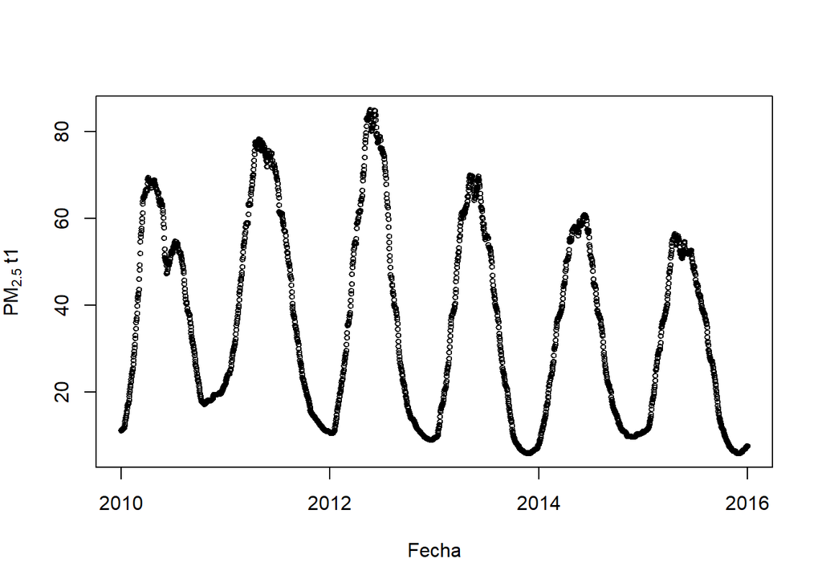

```r
plot(t1 ~ fechaini, ts, cex=0.6, ylab=expression(PM[2.5]~t1), xlab="Fecha")
```

```r
summary(ts)
```

```
    fechaini                t1              N
 Min.   :2010-01-01   Min.   : 5.86   Min.   : 1.000
 1st Qu.:2011-07-02   1st Qu.:14.56   1st Qu.: 4.000
 Median :2012-12-31   Median :32.36   Median : 6.000
 Mean   :2012-12-31   Mean   :35.68   Mean   : 5.904
 3rd Qu.:2014-07-01   3rd Qu.:54.37   3rd Qu.: 7.000
 Max.   :2015-12-31   Max.   :85.01   Max.   :16.000
                                      NA's   :5
```

### Visualizar pm ts

Así se ve la serie.

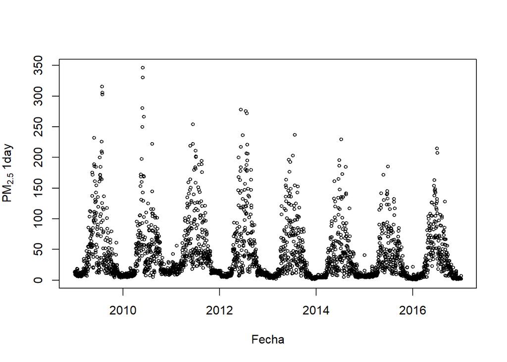

```r
plot(PM25LE ~ fecha, pmts, cex=0.6, ylab=expression(PM[2.5]~"1day"), xlab="Fecha")
```

```r
summary(pmts)
```

```
     fecha                PM25LE             year
 Min.   :2009-01-01   Min.   :  1.000   Min.   :2009
 1st Qu.:2011-01-01   1st Qu.:  9.276   1st Qu.:2011
 Median :2012-12-31   Median : 19.988   Median :2012
 Mean   :2012-12-31   Mean   : 38.221   Mean   :2013
 3rd Qu.:2014-12-31   3rd Qu.: 49.724   3rd Qu.:2015
 Max.   :2016-12-31   Max.   :346.363   Max.   :2016
```

Usar **filter**.

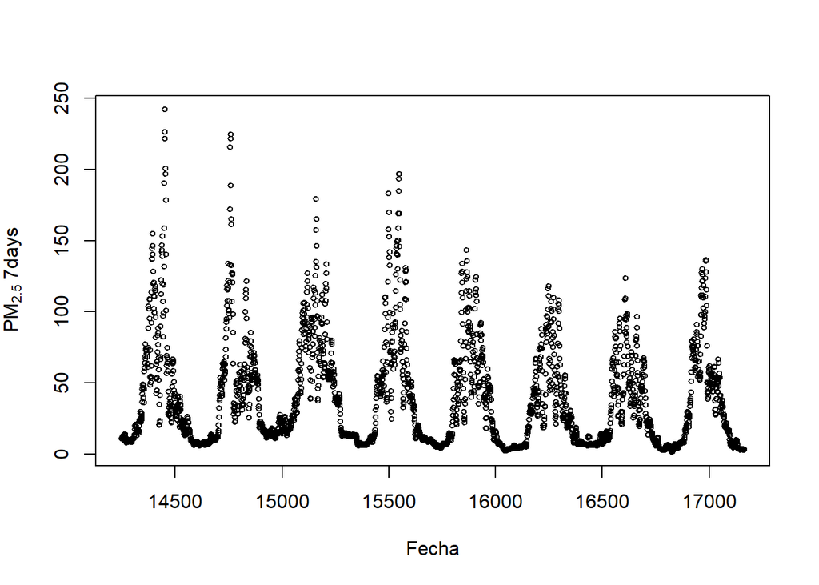

```r
pmts$f7<-filter(pmts$PM25LE, rep((1/7),7))
plot(f7 ~ fecha, pmts, cex=0.6, ylab=expression(PM[2.5]~"7days"), xlab="Fecha")
```

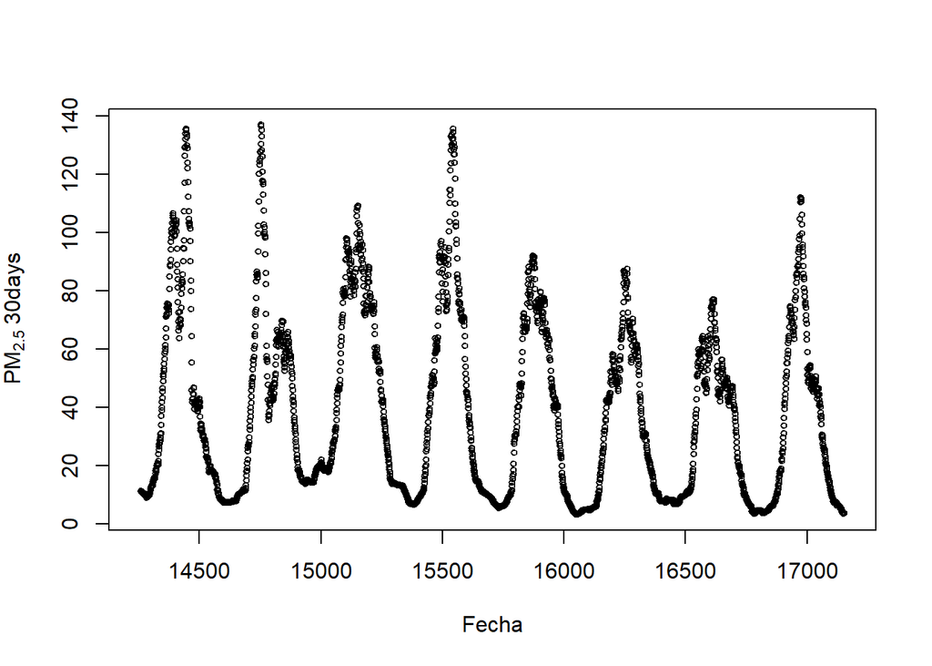

```r
pmts$f30<-filter(pmts$PM25LE, rep((1/30),30))
plot(f30 ~ fecha, pmts, cex=0.6, ylab=expression(PM[2.5]~"30days"), xlab="Fecha")
```

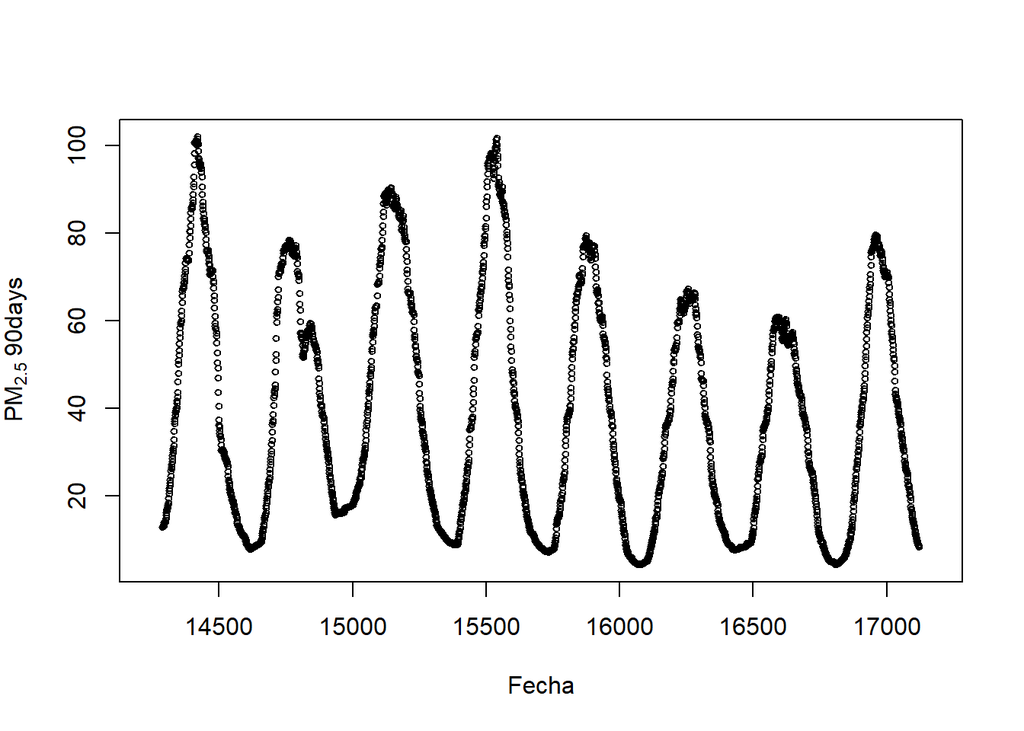

```r
pmts$f90<-filter(pmts$PM25LE, rep((1/90),90))
plot(f90 ~ fecha, pmts, cex=0.6, ylab=expression(PM[2.5]~"90days"), xlab="Fecha")
```

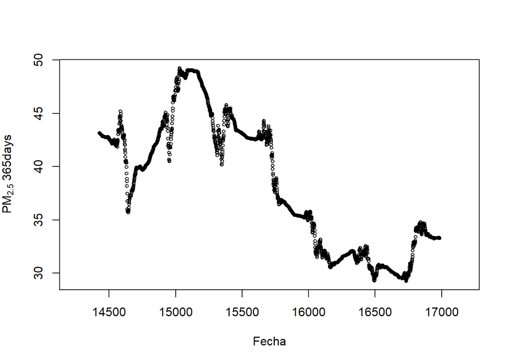

```r
pmts$f365<-filter(pmts$PM25LE, rep((1/365),365))
plot(f365 ~ fecha, pmts, cex=0.6, ylab=expression(PM[2.5]~"365days"), xlab="Fecha")
```

**¿Why are there so big jumps in 365 days filters?**

### Modelo más simple, lineal: pm from women

```r
model<-lm(t1 ~ fechaini, ts)
summary(model)
```

```
Call:
lm(formula = t1 ~ fechaini, data = ts)

Residuals:
    Min      1Q  Median      3Q     Max
-34.992 -19.282  -3.032  20.134  47.280

Coefficients:
              Estimate Std. Error t value Pr(>|t|)
(Intercept)  1.857e+02  1.139e+01   16.31   <2e-16 ***
fechaini    -9.550e-03  7.244e-04  -13.18   <2e-16 ***
---
Signif. codes:  0 '***' 0.001 '**' 0.01 '*' 0.05 '.' 0.1 ' ' 1

Residual standard error: 21.45 on 2189 degrees of freedom
Multiple R-squared:  0.07357,   Adjusted R-squared:  0.07314
F-statistic: 173.8 on 1 and 2189 DF,  p-value: < 2.2e-16
```

Pareciera ir **disminuyendo**

### Modelo más simple, lineal: pm from ts

```r
model<-lm(PM25LE ~ fecha, pmts)
summary(model)
```

```
Call:
lm(formula = PM25LE ~ fecha, data = pmts)

Residuals:
   Min     1Q Median     3Q    Max
-40.70 -28.01 -18.19  11.59 302.71

Coefficients:
              Estimate Std. Error t value Pr(>|t|)
(Intercept)  1.284e+02  1.520e+01   8.446  < 2e-16 ***
fecha       -5.741e-03  9.665e-04  -5.940 3.18e-09 ***
---
Signif. codes:  0 '***' 0.001 '**' 0.01 '*' 0.05 '.' 0.1 ' ' 1

Residual standard error: 44.07 on 2920 degrees of freedom
Multiple R-squared:  0.01194,   Adjusted R-squared:  0.0116
F-statistic: 35.29 on 1 and 2920 DF,  p-value: 3.184e-09
```

Pareciera ir **disminuyendo** menos rápido que mujeres. ¿Efecto 2009?

### Simple splines: pm from women

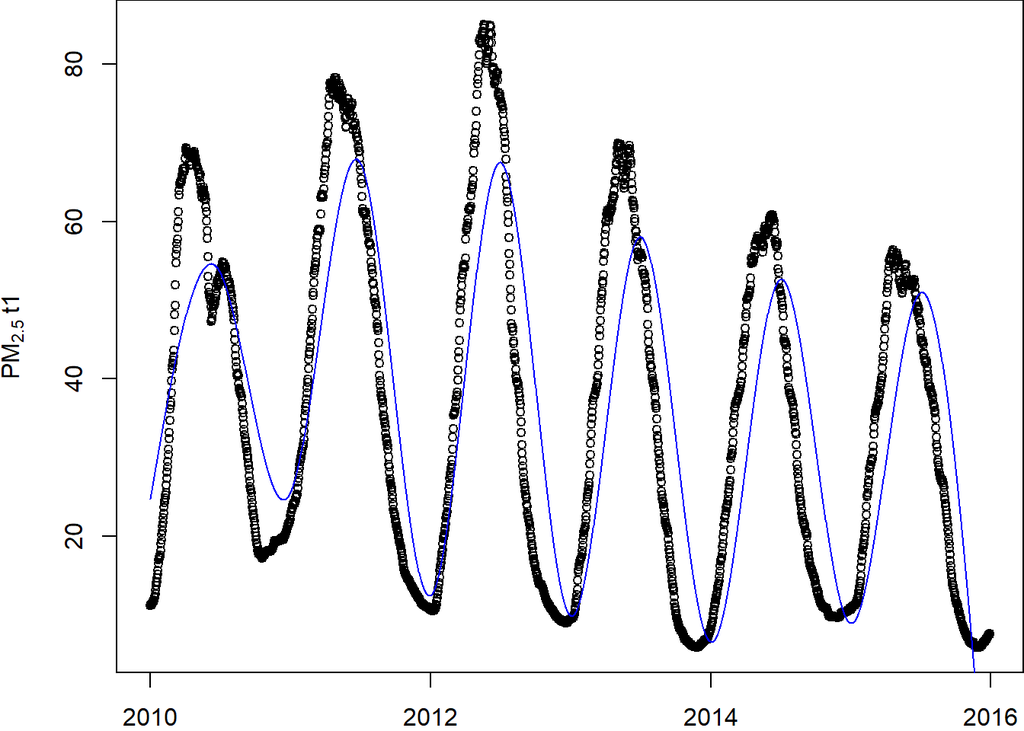

```r
# Modelo con ns
model <- lm(t1 ~ ns(fechaini, df = 2 * 6), ts)

# plot
par(mar = c(2, 4, 0, 0))
plot(t1 ~ fechaini, ylab = expression(PM[2.5] ~ t1), cex = 0.8, data=ts)
lines(ts$fechaini, predict(model, fechaini=ts$fechaini), col="blue")
```

Modelo con ns se ve desfasado pues hay 2 df por año. Obliga a tener peaks in ene y jun. Como t1 es promedio de primer trimestre de fecha ini, t1 representa PM desde fecha ini a 1 mes más. Ej marzo 1 incluye marzo a mayo entonces se anticipa el peak. **¡Ojo hombro en 2010!**.

### Simple splines: pm from ts

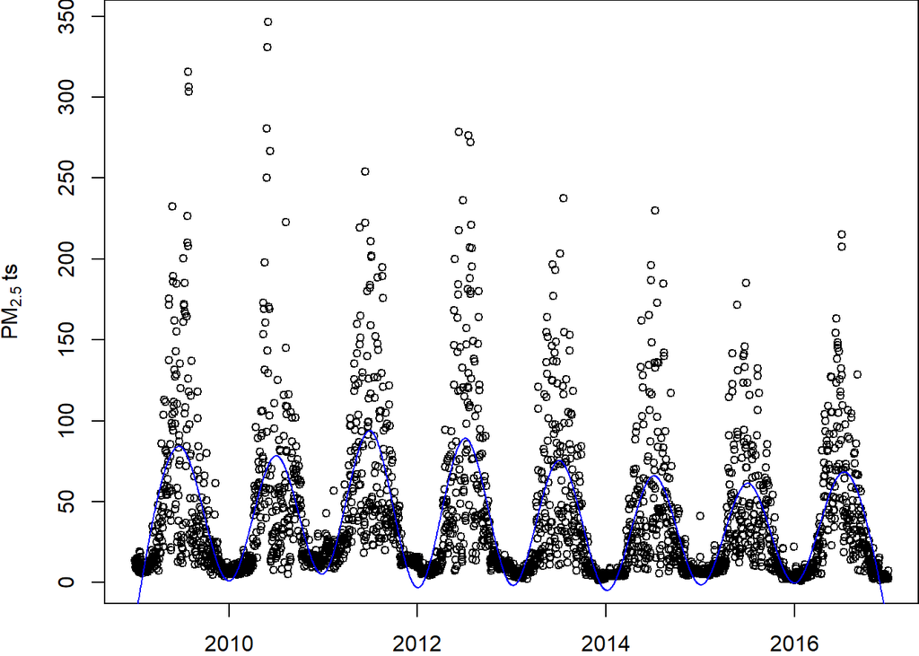

```r
# Modelo con ns
model <- lm(PM25LE ~ ns(fecha, df = 2 * 8), pmts)

# plot
par(mar = c(2, 4, 0, 0))
plot(PM25LE ~ fecha, ylab = expression(PM[2.5] ~ ts), cex = 0.8, data=pmts)
lines(pmts$fecha, predict(model, fecha=pmts$fecha), col="blue")
```

PM como ts ajusta bien la temporalidad, mínimos en enero y máximos en junio.

## 5.2 autocorrelation

### Autocorrelación para PM data women

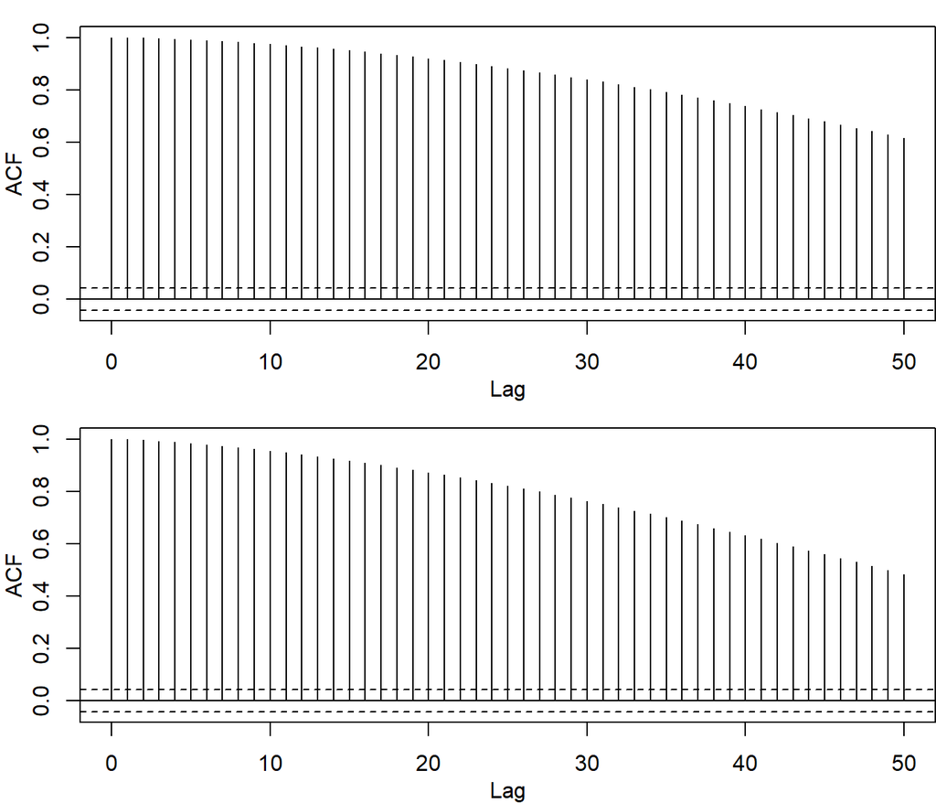

```r
# set par
par(mfrow=c(2,1), mar = c(3, 3, 1, 0), mgp=c(2,1,0))

# Autocorrelación simple
acf(ts$t1, lag.max = 50, main = "(a) t1 autocorrelación", ci.col = "black")

# Remove seasonal parcialmente
model <- lm(ts$t1 ~ ns(ts$fechaini, 2 * 6))
resid <- resid(model)
acf(resid, lag.max = 50, main = "(b) t1 autocorrelacion (seasonality removed)",
    ci.col = "black")
```

Se mantiene seasonality porque modelo simple de ns no ajusta bien al t1.

### Autocorrelación para PM ts

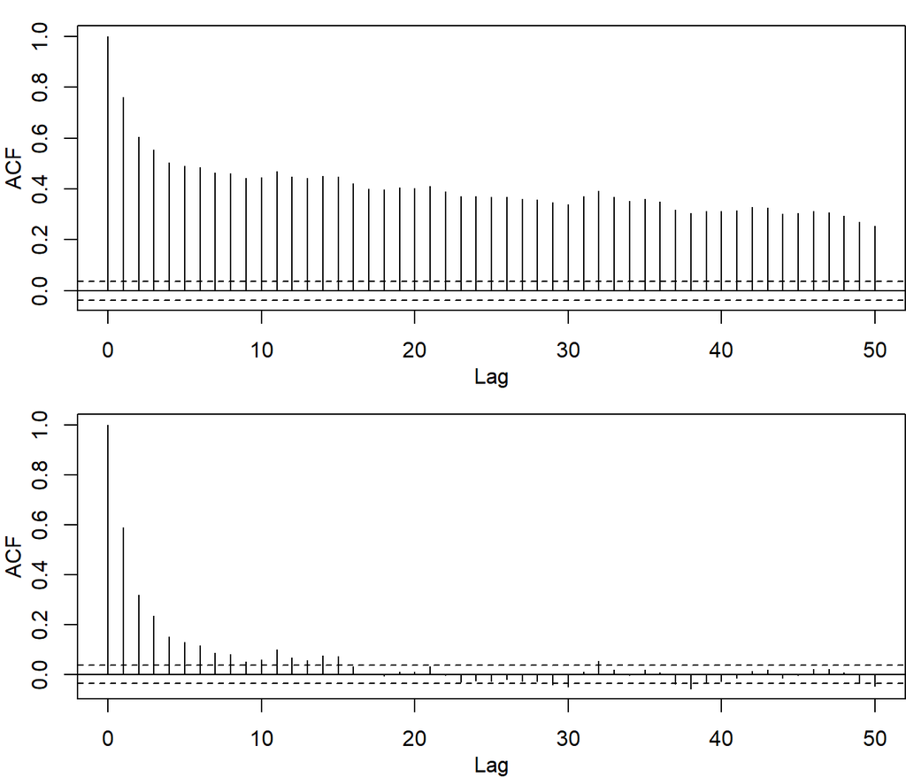

```r
# set par
par(mfrow=c(2,1), mar = c(3, 3, 1, 0), mgp=c(2,1,0))

# Autocorrelación simple
acf(pmts$PM25LE, lag.max = 50, main = "(a) PM ts autocorrelación", ci.col = "black")

# Remove seasonal parcialmente
model <- lm(pmts$PM25LE ~ ns(pmts$fecha, 2 * 8))
resid <- resid(model)
acf(resid, lag.max = 50, main = "(b) PM ts autocorrelacion (seasonality removed)",
    ci.col = "black")
```

Se elimina grandemente la autocorrelación. Queda en pocos días.

## 5.3 Explore timescale decompositions (page 50)

### 5.3.1 Decompose PM data women

### Simple model

```r
model<-lm(t1 ~ fechaini, ts)
summary(model)
```

```
Call:
lm(formula = t1 ~ fechaini, data = ts)

Residuals:
    Min      1Q  Median      3Q     Max
-34.992 -19.282  -3.032  20.134  47.280

Coefficients:
              Estimate Std. Error t value Pr(>|t|)
(Intercept)  1.857e+02  1.139e+01   16.31   <2e-16 ***
fechaini    -9.550e-03  7.244e-04  -13.18   <2e-16 ***
---
Signif. codes:  0 '***' 0.001 '**' 0.01 '*' 0.05 '.' 0.1 ' ' 1

Residual standard error: 21.45 on 2189 degrees of freedom
Multiple R-squared:  0.07357,   Adjusted R-squared:  0.07314
F-statistic: 173.8 on 1 and 2189 DF,  p-value: < 2.2e-16
```

### Filters

```r
### Filter year
ts$t1_y <-stats::filter(ts$t1, rep(1/365, 365))
ts$t1_ry<-ts$t1-ts$t1_y
ts$t1_s <-filter(ts$t1_ry, rep(1/90, 90))
ts$t1_rs<-ts$t1_ry-ts$t1_s
ts$t1_w <- filter(ts$t1_rs, rep(1/7, 7))
ts$t1_r <- ts$t1_rs-ts$t1_w

model <- lm(ts$t1 ~ ts$t1_y + ts$t1_s + ts$t1_w + ts$t1_r)
summary(model)
```

```
Call:
lm(formula = ts$t1 ~ ts$t1_y + ts$t1_s + ts$t1_w + ts$t1_r)

Residuals:
       Min         1Q     Median         3Q        Max
-6.213e-13 -1.520e-15  6.000e-17  1.710e-15  7.211e-13

Coefficients:
             Estimate Std. Error   t value Pr(>|t|)
(Intercept) 4.371e-14  4.163e-15 1.050e+01   <2e-16 ***
ts$t1_y     1.000e+00  1.138e-16 8.786e+15   <2e-16 ***
ts$t1_s     1.000e+00  4.866e-17 2.055e+16   <2e-16 ***
ts$t1_w     1.000e+00  3.335e-16 2.999e+15   <2e-16 ***
ts$t1_r     1.000e+00  1.857e-15 5.385e+14   <2e-16 ***
---
Signif. codes:  0 '***' 0.001 '**' 0.01 '*' 0.05 '.' 0.1 ' ' 1

Residual standard error: 2.473e-14 on 1727 degrees of freedom
  (459 observations deleted due to missingness)
Multiple R-squared:      1, Adjusted R-squared:      1
F-statistic: 3.598e+32 on 4 and 1727 DF,  p-value: < 2.2e-16
```

```r
# Predict

pr <- predict(model, type = "terms")
summary(pr)
```

```
    ts$t1_y            ts$t1_s           ts$t1_w           ts$t1_r
 Min.   :-6.75467   Min.   :-26.957   Min.   :-5.1339   Min.   :-1.442370
 1st Qu.:-5.58704   1st Qu.:-18.381   1st Qu.:-2.0100   1st Qu.:-0.126774
 Median : 0.04238   Median : -3.794   Median :-0.7533   Median : 0.005783
 Mean   : 0.00000   Mean   :  0.000   Mean   : 0.0000   Mean   : 0.000000
 3rd Qu.: 4.24461   3rd Qu.: 18.859   3rd Qu.: 1.7818   3rd Qu.: 0.127518
 Max.   : 8.78449   Max.   : 39.232   Max.   : 9.0504   Max.   : 1.332643
```

```r
class(pr)
```

```
[1] "matrix" "array"
```

```r
dim(pr)
```

```
[1] 1732    4
```

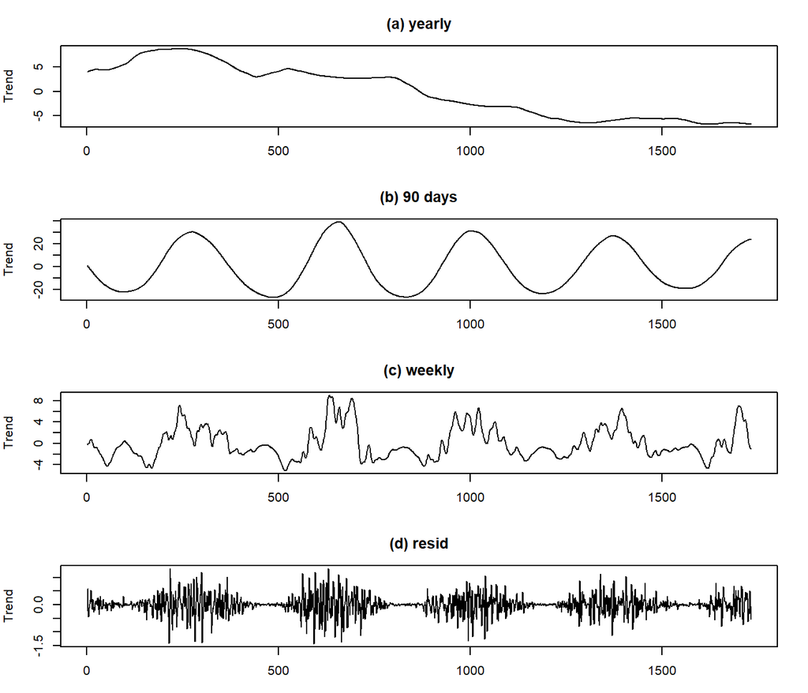

```r
### Plots
par(mfrow = c(4, 1), mar = c(3, 4, 3, 2) )
plot(pr[, 1], type = "l", ylab = "Trend", main = "(a) yearly")
plot(pr[, 2], type = "l", ylab = "Trend", main = "(b) 90 days")
plot(pr[, 3], type = "l", ylab = "Trend", main = "(c) weekly")
plot(pr[, 4], type = "l", ylab = "Trend", main = "(d) resid")
```

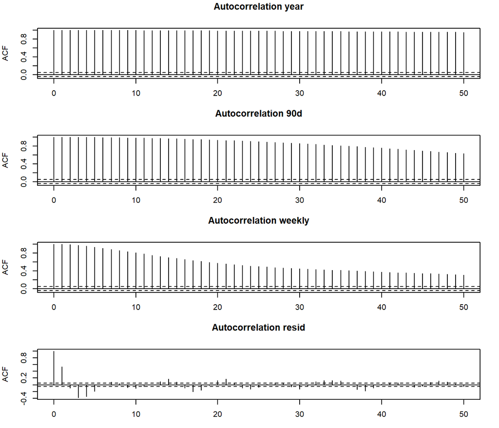

```r
### ACF

par(mfrow = c(4, 1), mar = c(3, 4, 3, 2) )
acf(pr[,1], lag.max = 50, main = "Autocorrelation year", ci.col = "black")
acf(pr[,2], lag.max = 50, main = "Autocorrelation 90d", ci.col = "black")
acf(pr[,3], lag.max = 50, main = "Autocorrelation weekly", ci.col = "black")
acf(pr[,4], lag.max = 50, main = "Autocorrelation resid", ci.col = "black")
```

### time decomposition using ts

```r
### library
library(tsModel)
### Decomposition
poll.dc <- tsdecomp(ts$t1, c(1, 2, 7, 2191))
class(poll.dc)
```

```
[1] "tsdecomp" "matrix"
```

```r
head(poll.dc)
```

```
         [,1]      [,2]     [,3]
[1,] 9.857329 -6.919533 8.205306
[2,] 9.884784 -6.605574 7.926485
[3,] 9.912283 -6.286287 7.655545
[4,] 9.939826 -5.961762 7.338967
[5,] 9.967411 -5.632092 7.048081
[6,] 9.995039 -5.297367 6.750609
```

```r
summary(poll.dc)
```

```
       V1               V2                V3
 Min.   : 4.783   Min.   :-24.892   Min.   :-4.180
 1st Qu.: 7.146   1st Qu.: -8.501   1st Qu.: 9.203
 Median :11.137   Median : 11.918   Median :11.669
 Mean   :11.893   Mean   : 11.893   Mean   :11.893
 3rd Qu.:16.803   3rd Qu.: 32.382   3rd Qu.:14.680
 Max.   :20.162   Max.   : 46.940   Max.   :27.815
```

```r
dim(poll.dc)
```

```
[1] 2191    3
```

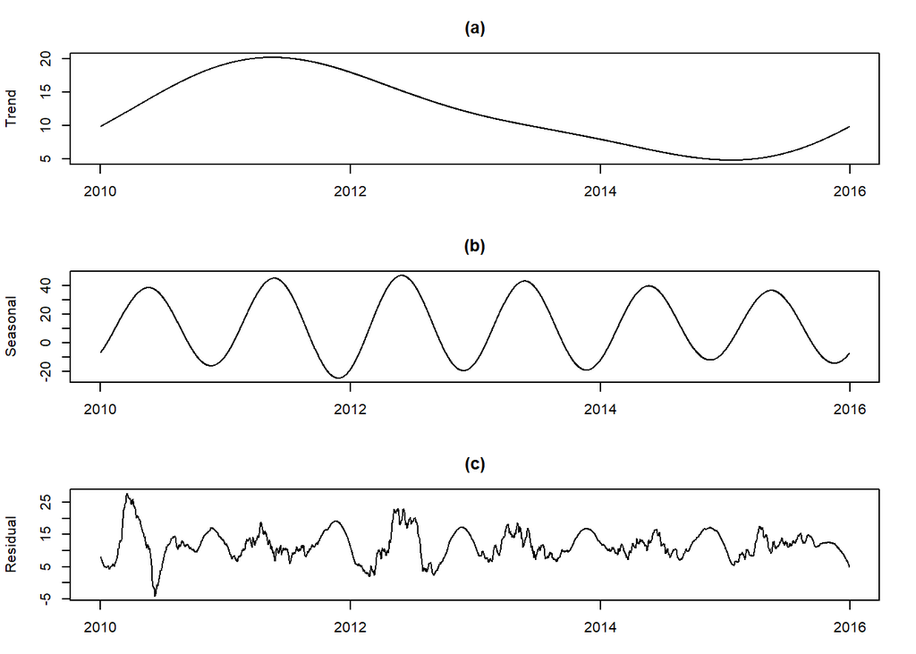

```r
### Plots
par(mfrow = c(3, 1), mar = c(3, 4, 3, 2) + 0.1)
plot(ts$fechaini, poll.dc[, 1], type = "l", ylab = "Trend", main = "(a)")
plot(ts$fechaini, poll.dc[, 2], type = "l", ylab = "Seasonal", main = "(b)")
plot(ts$fechaini, poll.dc[, 3], type = "l", ylab = "Residual", main = "(c)")
mtext("PM from women", outer=T)
```

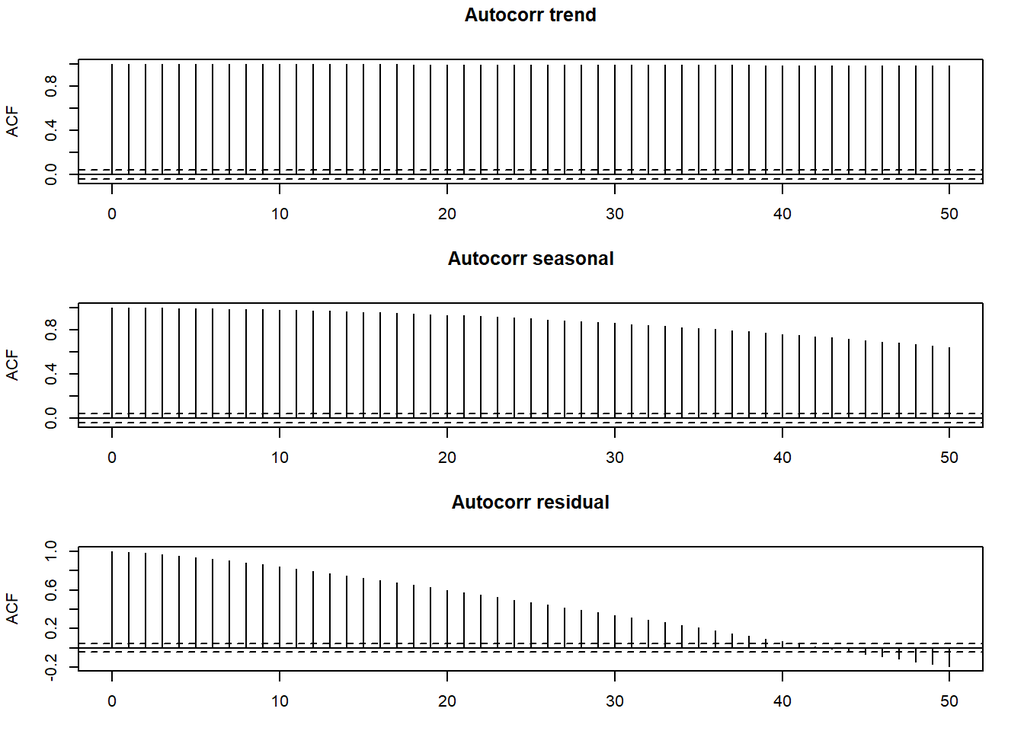

```r
### ACF

par(mfrow = c(3, 1), mar = c(3, 4, 3, 2) + 0.1)
acf(poll.dc[, 1], lag.max = 50, main = "Autocorr trend", ci.col = "black")
acf(poll.dc[, 2], lag.max = 50, main = "Autocorr seasonal", ci.col = "black")
acf(poll.dc[, 3], lag.max = 50, main = "Autocorr residual", ci.col = "black")
```

### 5.3.2 Decompose PM ts

### Simple model

```r
model<-lm(PM25LE ~ fecha, pmts)
summary(model)
```

```
Call:
lm(formula = PM25LE ~ fecha, data = pmts)

Residuals:
   Min     1Q Median     3Q    Max
-40.70 -28.01 -18.19  11.59 302.71

Coefficients:
              Estimate Std. Error t value Pr(>|t|)
(Intercept)  1.284e+02  1.520e+01   8.446  < 2e-16 ***
fecha       -5.741e-03  9.665e-04  -5.940 3.18e-09 ***
---
Signif. codes:  0 '***' 0.001 '**' 0.01 '*' 0.05 '.' 0.1 ' ' 1

Residual standard error: 44.07 on 2920 degrees of freedom
Multiple R-squared:  0.01194,   Adjusted R-squared:  0.0116
F-statistic: 35.29 on 1 and 2920 DF,  p-value: 3.184e-09
```

### Filters

```r
### Filter year
pmts$pm_y <-stats::filter(pmts$PM25LE, rep(1/365, 365))
pmts$pm_ry<-pmts$PM25LE-pmts$pm_y
pmts$pm_s <-filter(pmts$pm_ry, rep(1/90, 90))
pmts$pm_rs<-pmts$pm_ry-pmts$pm_s
pmts$pm_w <- filter(pmts$pm_rs, rep(1/7, 7))
pmts$pm_r <- pmts$pm_rs-pmts$pm_w

model <- lm(pmts$PM25LE ~ pmts$pm_y + pmts$pm_s + pmts$pm_w + pmts$pm_r)
summary(model)
```

```
Call:
lm(formula = pmts$PM25LE ~ pmts$pm_y + pmts$pm_s + pmts$pm_w +
    pmts$pm_r)

Residuals:
       Min         1Q     Median         3Q        Max
-4.214e-12 -2.500e-15  2.200e-15  9.000e-15  6.300e-14

Coefficients:
              Estimate Std. Error    t value Pr(>|t|)
(Intercept) -5.040e-14  1.468e-14 -3.434e+00 0.000604 ***
pmts$pm_y    1.000e+00  3.790e-16  2.639e+15  < 2e-16 ***
pmts$pm_s    1.000e+00  9.188e-17  1.088e+16  < 2e-16 ***
pmts$pm_w    1.000e+00  1.252e-16  7.986e+15  < 2e-16 ***
pmts$pm_r    1.000e+00  1.004e-16  9.955e+15  < 2e-16 ***
---
Signif. codes:  0 '***' 0.001 '**' 0.01 '*' 0.05 '.' 0.1 ' ' 1

Residual standard error: 1.144e-13 on 2458 degrees of freedom
  (459 observations deleted due to missingness)
Multiple R-squared:      1, Adjusted R-squared:      1
F-statistic: 8.462e+31 on 4 and 2458 DF,  p-value: < 2.2e-16
```

```r
# Predict

pr <- predict(model, type = "terms")
summary(pr)
```

```
   pmts$pm_y         pmts$pm_s         pmts$pm_w         pmts$pm_r
 Min.   :-8.9849   Min.   :-34.026   Min.   :-71.133   Min.   :-110.738
 1st Qu.:-6.2839   1st Qu.:-23.549   1st Qu.: -7.389   1st Qu.:  -6.150
 Median :-0.1314   Median : -5.813   Median : -1.973   Median :  -0.554
 Mean   : 0.0000   Mean   :  0.000   Mean   :  0.000   Mean   :   0.000
 3rd Qu.: 4.7931   3rd Qu.: 23.079   3rd Qu.:  2.982   3rd Qu.:   2.861
 Max.   :11.0101   Max.   : 60.393   Max.   :148.294   Max.   : 158.569
```

```r
class(pr)
```

```
[1] "matrix" "array"
```

```r
dim(pr)
```

```
[1] 2463    4
```

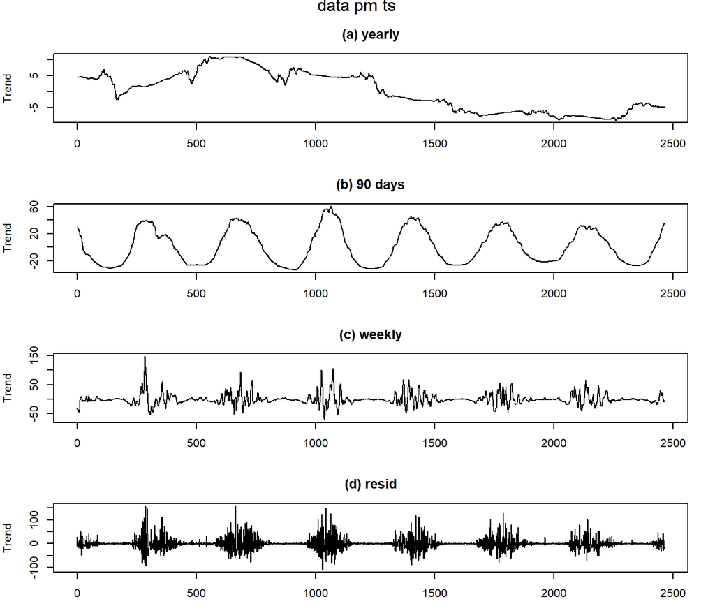

```r
### Plots
par(mfrow = c(4, 1), mar = c(3, 4, 3, 2), oma=c(0,0,1,0))
plot(pr[, 1], type = "l", ylab = "Trend", main = "(a) yearly")
plot(pr[, 2], type = "l", ylab = "Trend", main = "(b) 90 days")
plot(pr[, 3], type = "l", ylab = "Trend", main = "(c) weekly")
plot(pr[, 4], type = "l", ylab = "Trend", main = "(d) resid")
mtext("data pm ts", outer=T)
```

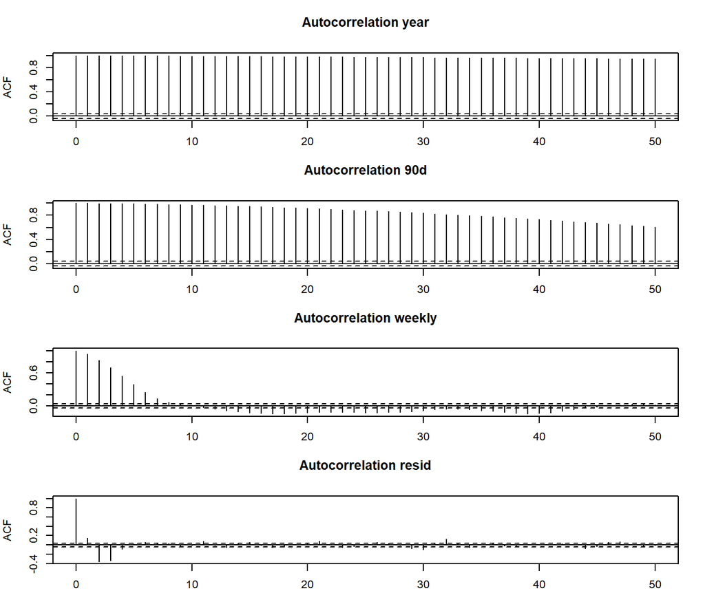

```r
### ACF

par(mfrow = c(4, 1), mar = c(3, 4, 3, 2) )
acf(pr[,1], lag.max = 50, main = "Autocorrelation year", ci.col = "black")
acf(pr[,2], lag.max = 50, main = "Autocorrelation 90d", ci.col = "black")
acf(pr[,3], lag.max = 50, main = "Autocorrelation weekly", ci.col = "black")
acf(pr[,4], lag.max = 50, main = "Autocorrelation resid", ci.col = "black")
```

### time decomposition using pm ts

```r
### Decomposition
poll.dc <- tsdecomp(pmts$PM25LE, c(1, 2, 9, 2922))
class(poll.dc)
```

```
[1] "tsdecomp" "matrix"
```

```r
head(poll.dc)
```

```
         [,1]      [,2]     [,3]
[1,] 12.16045 -27.34450 28.94655
[2,] 12.17350 -27.21904 27.59554
[3,] 12.18654 -27.08182 26.71195
[4,] 12.19957 -26.93286 24.01246
[5,] 12.21259 -26.77220 24.90128
[6,] 12.22560 -26.59988 22.79095
```

```r
summary(poll.dc)
```

```
       V1               V2               V3
 Min.   : 4.206   Min.   :-34.73   Min.   :-61.393
 1st Qu.: 7.279   1st Qu.:-15.19   1st Qu.: -4.019
 Median :13.237   Median : 12.71   Median : 11.519
 Mean   :12.740   Mean   : 12.74   Mean   : 12.740
 3rd Qu.:18.143   3rd Qu.: 40.41   3rd Qu.: 21.285
 Max.   :20.400   Max.   : 60.19   Max.   :285.864
```

```r
dim(poll.dc)
```

```
[1] 2922    3
```

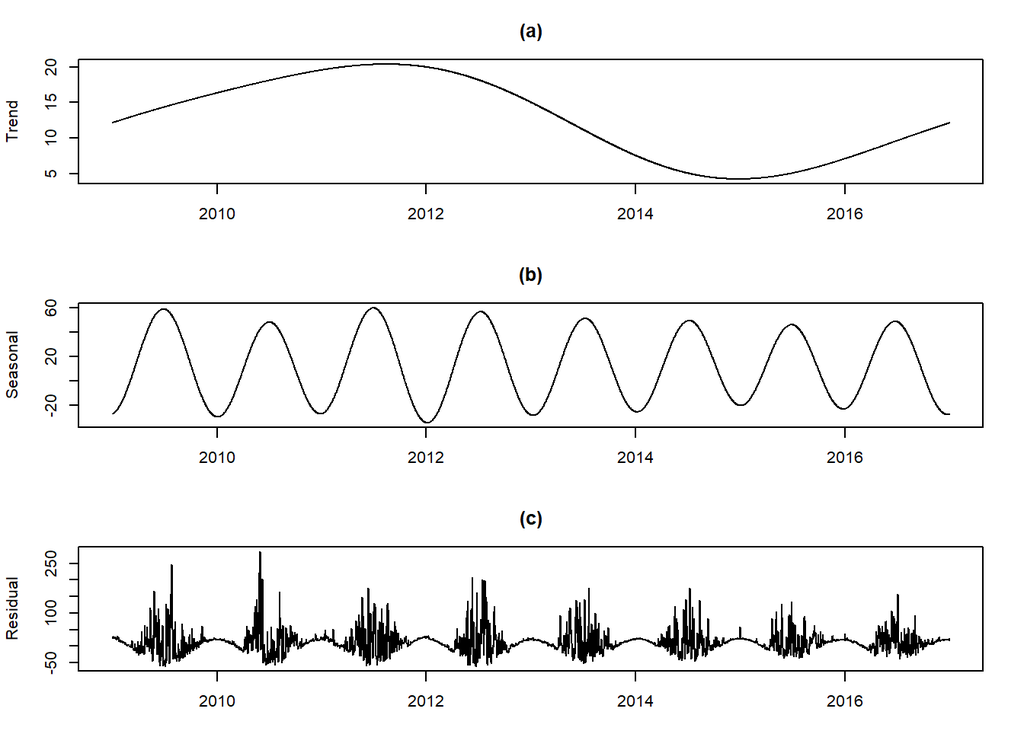

```r
### Plots
par(mfrow = c(3, 1), mar = c(3, 4, 3, 2) + 0.1)
plot(pmts$fecha, poll.dc[, 1], type = "l", ylab = "Trend", main = "(a)")
plot(pmts$fecha, poll.dc[, 2], type = "l", ylab = "Seasonal", main = "(b)")
plot(pmts$fecha, poll.dc[, 3], type = "l", ylab = "Residual", main = "(c)")
mtext("PM from ts", outer=T)
```

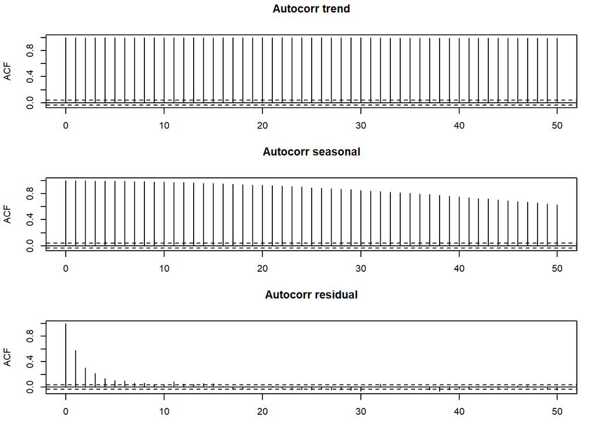

```r
### ACF

par(mfrow = c(3, 1), mar = c(3, 4, 3, 2) + 0.1)
acf(poll.dc[, 1], lag.max = 50, main = "Autocorr trend", ci.col = "black")
acf(poll.dc[, 2], lag.max = 50, main = "Autocorr seasonal", ci.col = "black")
acf(poll.dc[, 3], lag.max = 50, main = "Autocorr residual", ci.col = "black")
```

From Dominici FD, McDermott A, Zeger SL, Samet JM (2003). “Airborne particulate matter and mortality: Timescale effects in four US cities”, American Journal of Epidemiology, 157 (12), 1055–1065.

### 5.3.3 More detail timescale: pm from women

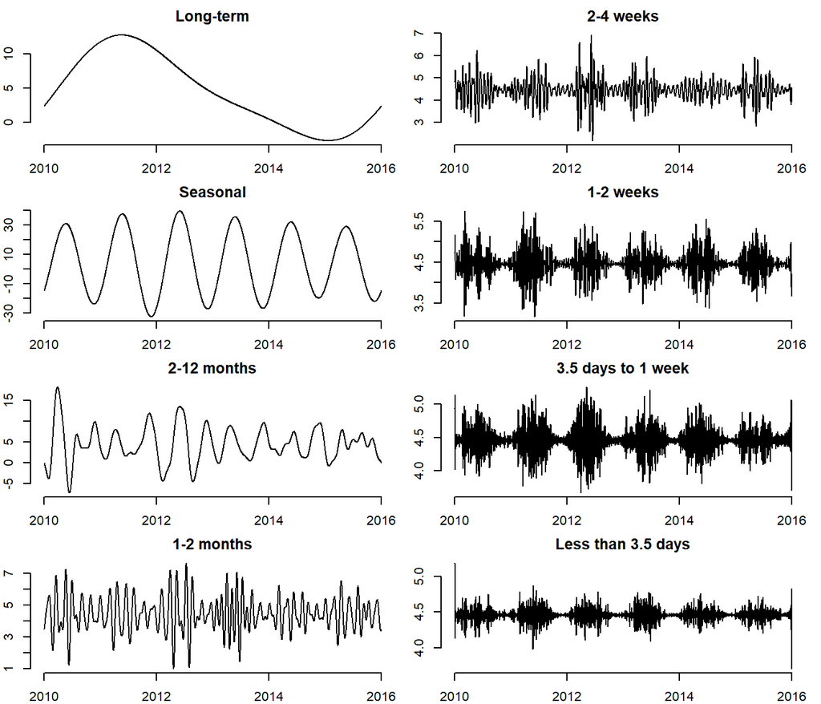

```r
### Create the decomposition

freq.cuts <- c(1, 2, 7, round(2191/c(60,30, 14, 7, 3.5)), 2191)
poll.dc <- tsdecomp(ts$t1, freq.cuts)
colnames(poll.dc) <- c("Long-term", "Seasonal","2-12 months", "1-2 months",
                       "2-4 weeks","1-2 weeks", "3.5 days to 1 week",
                       "Less than 3.5 days")

### PLOT

par(mfcol = c(4, 2), mar = c(2, 2, 2,1))
cn <- colnames(poll.dc)
for (i in 1:8)
  {
  plot(ts$fechaini, poll.dc[, i], type = "l",
  frame.plot = FALSE, main = cn[i],
  ylab = "")
  }
```

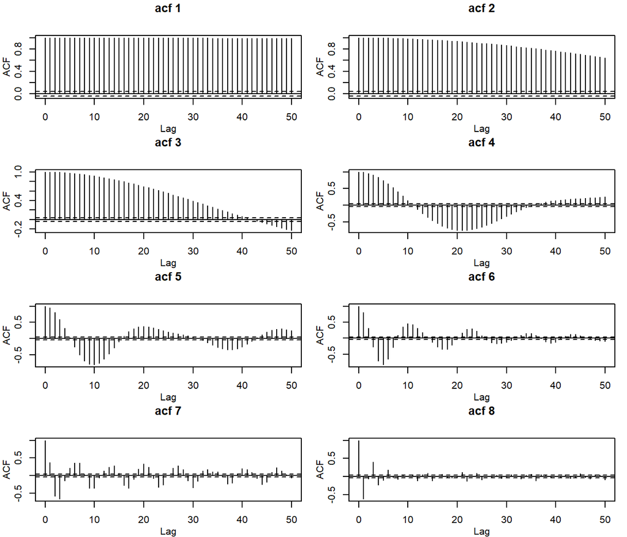

```r
### ACF

par(mfrow = c(4, 2), mar = c(3, 3, 3, 1), mgp=c(2,1,0))
for (i in 1:8)
{
  acf(poll.dc[, i], lag.max = 50, main = paste("acf",i), ci.col = "black")
}
```

### 5.3.4 More detail timescale: pm from ts

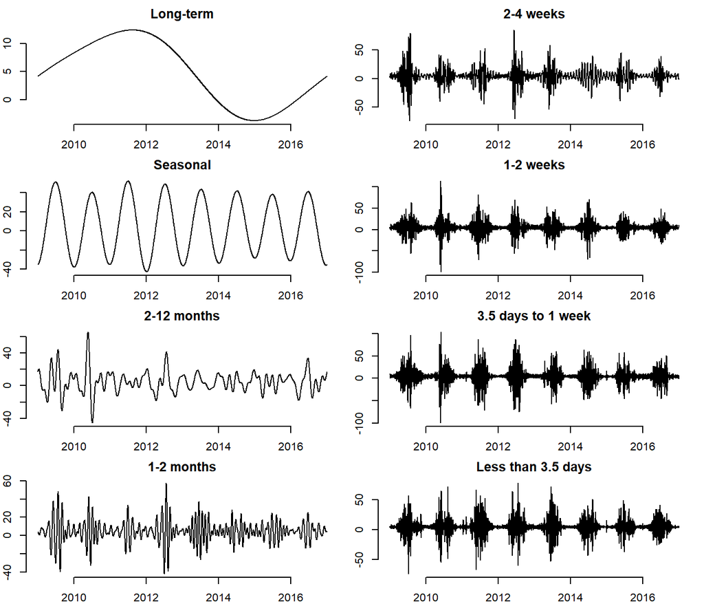

```r
### Create the decomposition

freq.cuts <- c(1, 2, 9, round(2922/c(60,30, 14, 7, 3.5)), 2922)
poll.dc <- tsdecomp(pmts$PM25LE, freq.cuts)
colnames(poll.dc) <- c("Long-term", "Seasonal","2-12 months", "1-2 months",
                       "2-4 weeks","1-2 weeks", "3.5 days to 1 week",
                       "Less than 3.5 days")

### PLOT

par(mfcol = c(4, 2), mar = c(2, 2, 2,1))
cn <- colnames(poll.dc)
for (i in 1:8)
  {
  plot(pmts$fecha, poll.dc[, i], type = "l",
  frame.plot = FALSE, main = cn[i],
  ylab = "")
  }
```

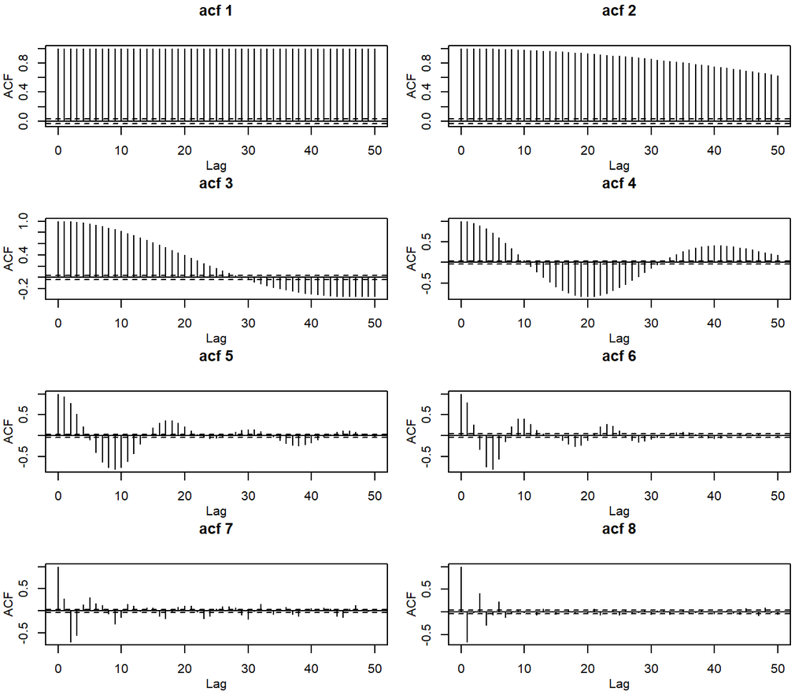

```r
### ACF

par(mfrow = c(4, 2), mar = c(3, 3, 3, 1), mgp=c(2,1,0))
for (i in 1:8)
{
  acf(poll.dc[, i], lag.max = 50, main = paste("acf",i), ci.col = "black")
}
```

# 6. Peng Chapter 6 (page 68) Statistical Models

## 6.1 Model PM with smooth

### 6.1.1 from women data

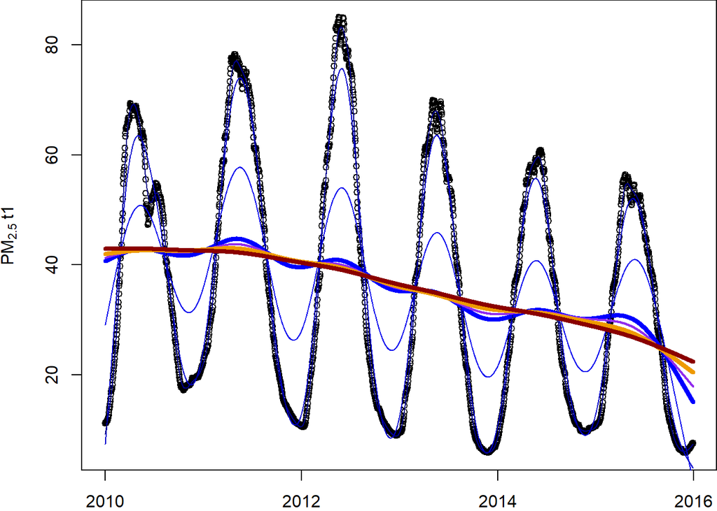

```r
library(gam)

### MODEL WITH GAM
model1 <- gam(ts$t1 ~ s(fechaini, 1 * 6), data = ts)
ts$t1_pr1 <- predict(model1, ts)

model2 <- gam(ts$t1 ~ s(fechaini, 2 * 6), data = ts)
ts$t1_pr2 <- predict(model2, ts)

model3 <- gam(ts$t1 ~ s(fechaini, 4 * 6), data = ts)
ts$t1_pr3 <- predict(model3, ts)

model4 <- gam(ts$t1 ~ s(fechaini, 12 * 6), data = ts)
ts$t1_pr4 <- predict(model4, ts)

model5 <- gam(ts$t1 ~ s(fechaini, 5), data = ts)
ts$t1_pr5 <- predict(model5, ts)

model6 <- gam(ts$t1 ~ s(fechaini, 4), data = ts)
ts$t1_pr6 <- predict(model6, ts)

model7 <- gam(ts$t1 ~ s(fechaini, 3), data = ts)
ts$t1_pr7 <- predict(model7, ts)


# plot
par(mar = c(2, 4, 0, 0))
plot(t1 ~ fechaini, ylab = expression(PM[2.5] ~ t1), cex = 0.8, data=ts)
lines(ts$fechaini, ts$t1_pr1, col="blue", lwd=4)
lines(ts$fechaini, ts$t1_pr2, col="blue2")
lines(ts$fechaini, ts$t1_pr3, col="blue3")
lines(ts$fechaini, ts$t1_pr4, col="blue4")
lines(ts$fechaini, ts$t1_pr5, col="purple2", lwd=2)
lines(ts$fechaini, ts$t1_pr6, col="orange2", lwd=4)
lines(ts$fechaini, ts$t1_pr7, col="darkred", lwd=4)
```

**¡OJO 2010!**

### 6.1.2 from pm ts

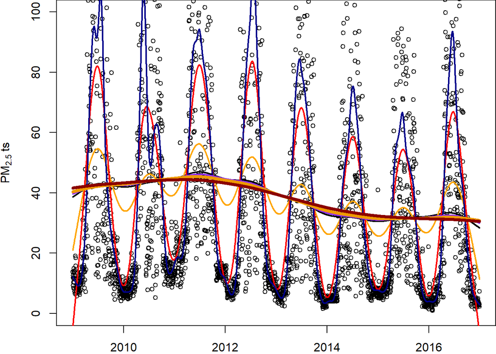

```r
library(gam)

### MODEL WITH GAM
model1 <- gam(pmts$PM25LE ~ s(fecha, 1 * 6), data = pmts)
pmts$pm_pr1 <- predict(model1, pmts)

model2 <- gam(pmts$PM25LE ~ s(fecha, 2 * 6), data = pmts)
pmts$pm_pr2 <- predict(model2, pmts)

model3 <- gam(pmts$PM25LE ~ s(fecha, 4 * 6), data = pmts)
pmts$pm_pr3 <- predict(model3, pmts)

model4 <- gam(pmts$PM25LE ~ s(fecha, 12 * 6), data = pmts)
pmts$pm_pr4 <- predict(model4, pmts)

model5 <- gam(pmts$PM25LE ~ s(fecha, 5), data = pmts)
pmts$pm_pr5 <- predict(model5, pmts)

model6 <- gam(pmts$PM25LE ~ s(fecha, 4), data = pmts)
pmts$pm_pr6 <- predict(model6, pmts)

model7 <- gam(pmts$PM25LE ~ s(fecha, 3), data = pmts)
pmts$pm_pr7 <- predict(model7, pmts)


# plot
par(mar = c(2, 4, 0, 0))
plot(PM25LE ~ fecha, ylab = expression(PM[2.5] ~ ts), cex = 0.8,
     ylim=c(0,100), data=pmts)
lines(pmts$fecha, pmts$pm_pr1, col="black", lwd=2)
lines(pmts$fecha, pmts$pm_pr2, col="orange", lwd=2)
lines(pmts$fecha, pmts$pm_pr3, col="red",lwd=2)
lines(pmts$fecha, pmts$pm_pr4, col="blue4",lwd=2)
lines(pmts$fecha, pmts$pm_pr5, col="purple2", lwd=2)
lines(pmts$fecha, pmts$pm_pr6, col="orange2", lwd=4)
lines(pmts$fecha, pmts$pm_pr7, col="darkred", lwd=4)
```

### 6.1.3 Two Smooths

```r
### MODEL WITH GAM
model1 <- gam(pmts$PM25LE ~ s(fecha, 1 * 5)+s(fecha, 4 * 7), data = pmts)
summary(model1)
```

```
Call: gam(formula = pmts$PM25LE ~ s(fecha, 1 * 5) + s(fecha, 4 * 7),
    data = pmts)
Deviance Residuals:
    Min      1Q  Median      3Q     Max
-74.550 -14.603  -3.788   4.082 274.085

(Dispersion Parameter for gaussian family taken to be 1103.261)

    Null Deviance: 5739686 on 2921 degrees of freedom
Residual Deviance: 3187322 on 2889 degrees of freedom
AIC: 28798.7

Number of Local Scoring Iterations: NA

Anova for Parametric Effects
                  Df  Sum Sq Mean Sq F value    Pr(>F)
s(fecha, 1 * 5)    1   68530   68530  62.116 4.548e-15 ***
Residuals       2889 3187322    1103
---
Signif. codes:  0 '***' 0.001 '**' 0.01 '*' 0.05 '.' 0.1 ' ' 1

Anova for Nonparametric Effects
                Npar Df Npar F  Pr(F)
(Intercept)
s(fecha, 1 * 5)       4  0.336 0.8537
s(fecha, 4 * 7)      27 83.140 <2e-16 ***
---
Signif. codes:  0 '***' 0.001 '**' 0.01 '*' 0.05 '.' 0.1 ' ' 1
```

```r
pr <- predict(model1, type="terms")
summary(pr)
```

```
 s(fecha, 1 * 5)   s(fecha, 4 * 7)
 Min.   :-9.4655   Min.   :-48.494
 1st Qu.:-4.1283   1st Qu.:-23.851
 Median : 0.6163   Median : -2.274
 Mean   : 0.0000   Mean   :  0.000
 3rd Qu.: 4.2851   3rd Qu.: 22.581
 Max.   : 7.2435   Max.   : 50.206
```

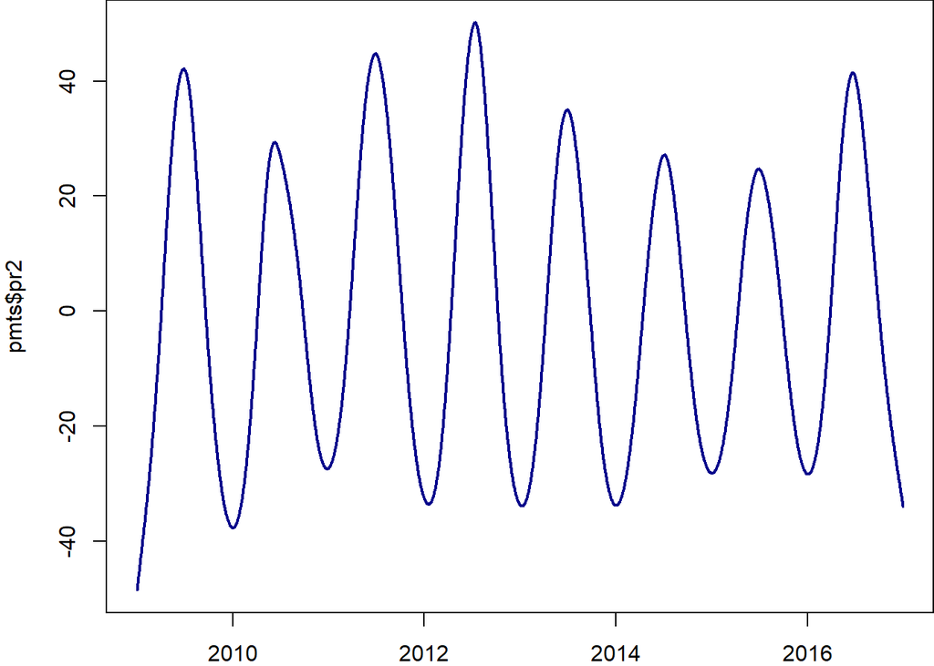

```r
pmts$pr1<-pr[,1]
pmts$pr2<-pr[,2]

# plot
par(mar = c(2, 4, 0, 0))
plot(pmts$fecha, pmts$pr2, col="darkblue", lwd=2, type="l")
```

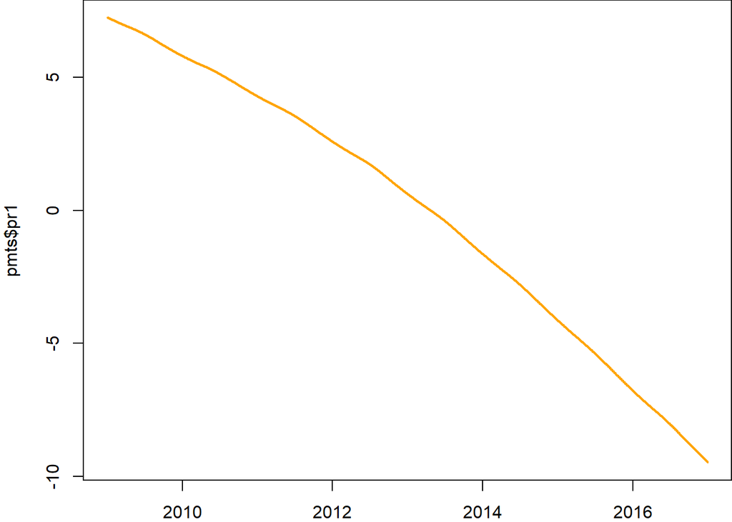

```r
plot(pmts$fecha, pmts$pr1, col="orange", lwd=2, type="l")
```

## 6.2 (page 90) Estimate df with bruto

### 6.2.1 Estimate for data from women

```r
library(mda)

## GET DF
br.fit<-bruto(ts$fechaini, ts$t1)
brdf<-br.fit$df
print(brdf)
```

```
[1] 115.1254
```

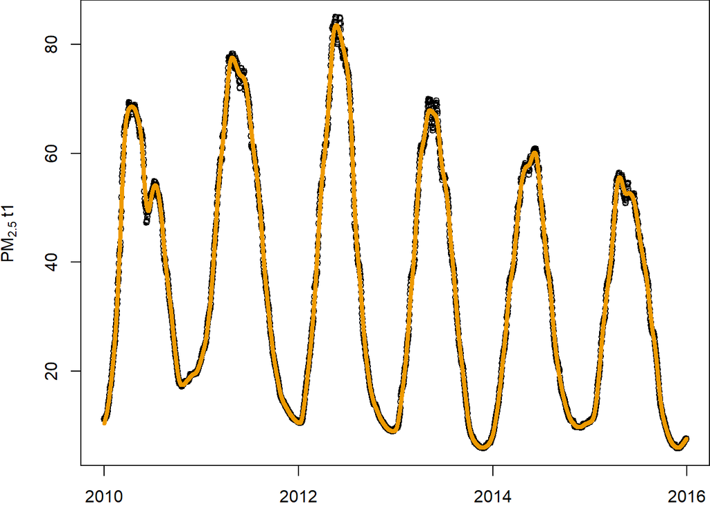

```r
## PREDICT
model1 <- gam(ts$t1 ~ s(fechaini, brdf), data = ts)
ts$t1_pr1 <- predict(model1, ts)

# plot
par(mar = c(2, 4, 0, 0))
plot(t1 ~ fechaini, ylab = expression(PM[2.5] ~ t1), cex = 0.8, data=ts)
lines(ts$fechaini, ts$t1_pr1, col="orange2", lwd=4)
```

### 6.2.2 Estimate for data from pm ts

```r
## GET DF
br.fit<-bruto(pmts$fecha, pmts$PM25LE)
brdf<-br.fit$df
print(brdf)
```

```
[1] 127.8058
```

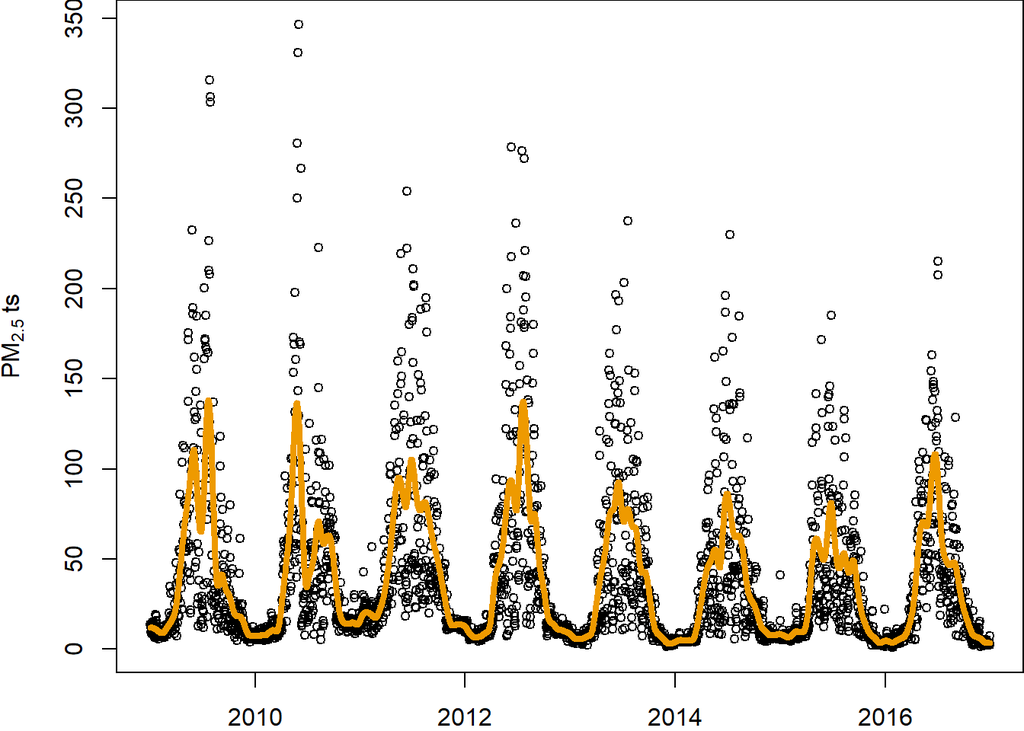

```r
## PREDICT
model1 <- gam(pmts$PM25LE ~ s(fecha, brdf), data = pmts)
pmts$pm_pr1 <- predict(model1, pmts)

# plot
par(mar = c(2, 4, 0, 0))
plot(PM25LE ~ fecha, ylab = expression(PM[2.5] ~ ts), cex = 0.8, data=pmts)
lines(pmts$fecha, pmts$pm_pr1, col="orange2", lwd=4)
```

# 7. Sin cosine

## 7.1 Preliminar

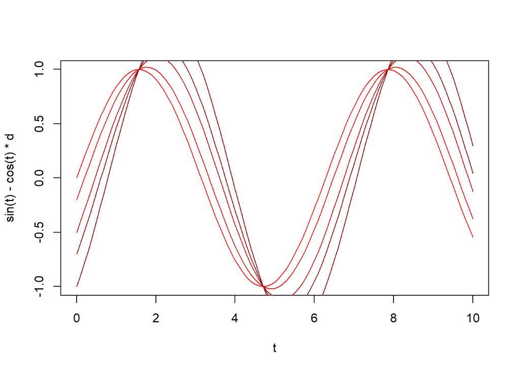

```r
t<-seq(0,10,0.1)

d=0
plot(sin(t)-cos(t)*d ~ t, type="l", col="red")
d=0.2
lines(sin(t)-cos(t)*d ~ t, type="l", col="red2")
d=0.5
lines(sin(t)-cos(t)*d ~ t, type="l", col="red3")
d=0.7
lines(sin(t)-cos(t)*d ~ t, type="l", col="red4")
d=1
lines(sin(t)-cos(t)*d ~ t, type="l", col="red4")
```

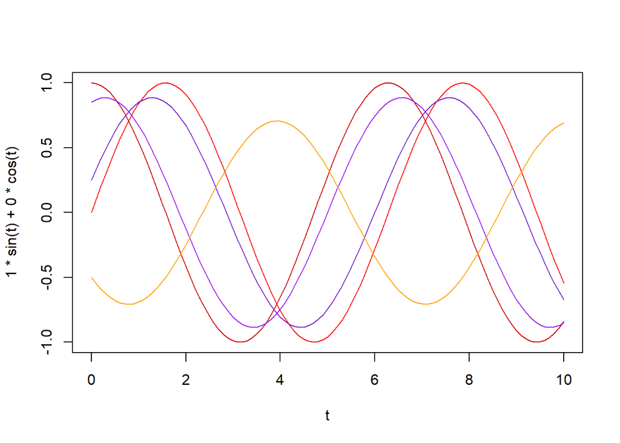

```r
plot(1*sin(t)+0*cos(t) ~ t, type="l", col="red")
lines(0*sin(t)+1*cos(t) ~ t, type="l", col="red3")
lines(0.25*sin(t)+0.85*cos(t) ~ t, type="l", col="purple")
lines(0.85*sin(t)+0.25*cos(t) ~ t, type="l", col="purple3")
lines(-0.5*sin(t)-0.5*cos(t) ~ t, type="l", col="orange")
```

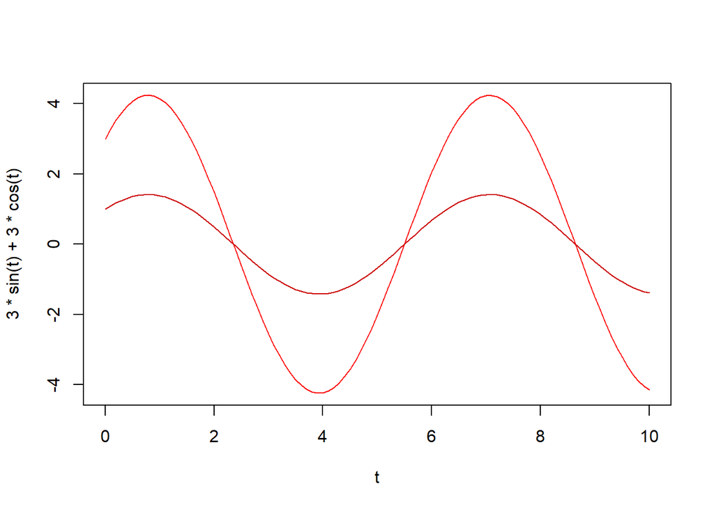

```r
plot(3*sin(t)+3*cos(t) ~ t, type="l", col="red")
lines(1*sin(t)+1*cos(t) ~ t, type="l", col="red3")
```